# Hands-on Exercise 4d: Funnel Plots for Fair Comparisons

Author

Htet Kay Khaing

Published

May 6, 2026

Modified

May 7, 2026

## 4.1 Overview

Funnel plot is a specially designed data visualisation for conducting unbiased comparison between outlets, stores or business entities. This section is about:

- plotting funnel plots by using **funnelPlotR** package,
- plotting static funnel plot by using ggplot2 package, and
- plotting interactive funnel plot by using both **plotly R** and **ggplot2** packages.

## 4.2 Installing and Launching R Packages

- **readr** for importing csv into R.
- **FunnelPlotR** for creating funnel plot.
- **ggplot2** for creating funnel plot manually.
- **knitr** for building static html table.
- **plotly** for creating interactive funnel plot.

```r
pacman::p_load(tidyverse, FunnelPlotR, plotly, knitr)
```

## 4.3 Importing Data

In this section, COVID-19_DKI_Jakarta will be used. The data was downloaded from [Open Data Covid-19 Provinsi DKI Jakarta portal](https://riwayat-file-covid-19-dki-jakarta-jakartagis.hub.arcgis.com/). For this hands-on exercise, we are going to compare the cumulative COVID-19 cases and death by sub-district (i.e. kelurahan) as at 31st July 2021, DKI Jakarta.

The code chunk below imports the data into R and save it into a tibble data frame object called *covid19*.

```r
covid19 <- read_csv("data/COVID-19_DKI_Jakarta.csv") %>%
  mutate_if(is.character, as.factor)
```

## 4.4 FunnelPlotR methods

[**FunnelPlotR**](https://nhs-r-community.github.io/FunnelPlotR/) package uses ggplot to generate funnel plots. It requires a `numerator` (events of interest), `denominator` (population to be considered) and `group`. The key arguments selected for customisation are:

- `limit`: plot limits (95 or 99).
- `label_outliers`: to label outliers (true or false).
- `Poisson_limits`: to add Poisson limits to the plot.
- `OD_adjust`: to add overdispersed limits to the plot.
- `xrange` and `yrange`: to specify the range to display for axes, acts like a zoom function.
- Other aesthetic components such as graph title, axis labels etc.

### 4.4.1 FunnelPlotR methods: The basic plot

The code chunk below plots a funnel plot.

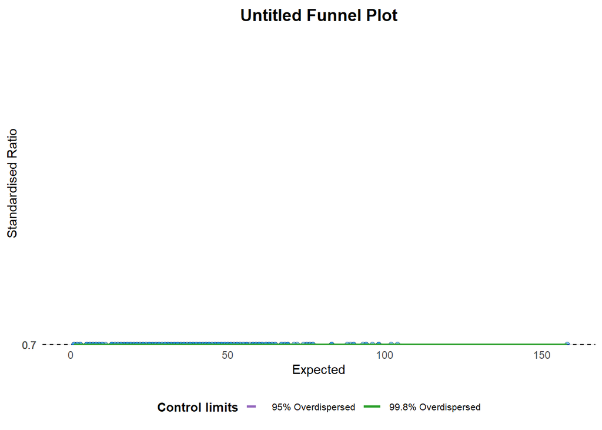

```
A funnel plot object with 267 points of which 0 are outliers.
Plot is adjusted for overdispersion.
```

```r
funnel_plot(
  .data = covid19,
  numerator = Positive,
  denominator = Death,
  group = `Sub-district`
)
```

**NoteThings to learn from the code chunk above**

- `group` in this function is different from the scatterplot. Here, it defines the level of the points to be plotted i.e. Sub-district, District or City. If Cityc is chosen, there are only six data points.
- By default, `data_typeargument` is “SR”.
- `limit`: Plot limits, accepted values are: 95 or 99, corresponding to 95% or 99.8% quantiles of the distribution.

### 4.4.2 FunnelPlotR methods: Makeover 1

The code chunk below plots a funnel plot.

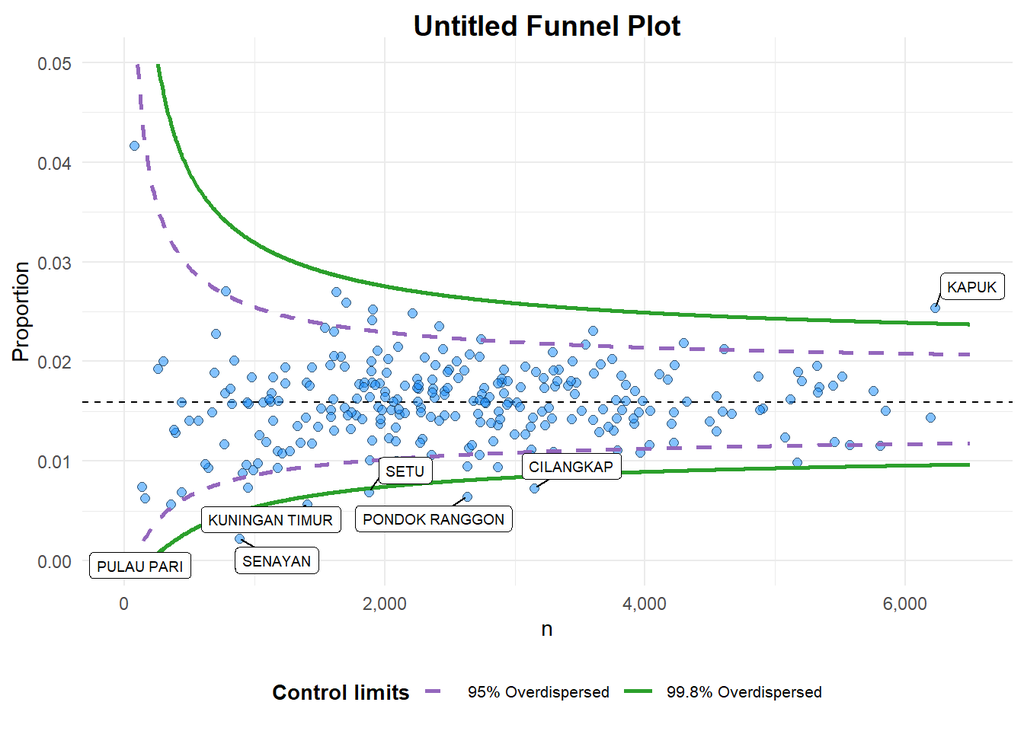

```
A funnel plot object with 267 points of which 7 are outliers.
Plot is adjusted for overdispersion.
```

```r
funnel_plot(
  .data = covid19,
  numerator = Death,
  denominator = Positive,
  group = `Sub-district`,
  data_type = "PR",     #<<
  xrange = c(0, 6500),  #<<
  yrange = c(0, 0.05)   #<<
)
```

**NoteThings to learn from the code chunk above**

- `data_type` argument is used to change from default “SR” to “PR” (i.e. proportions).
- `xrange` and `yrange` are used to set the range of x-axis and y-axis

### 4.4.3 FunnelPlotR methods: Makeover 2

The code chunk below plots a funnel plot.

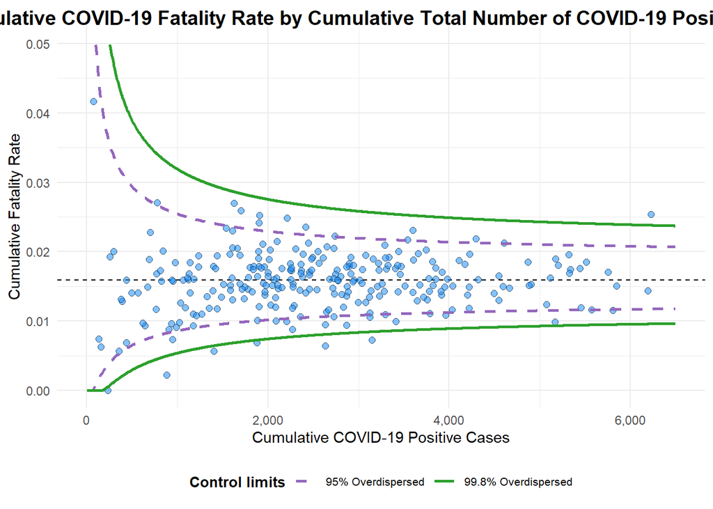

```
A funnel plot object with 267 points of which 7 are outliers.
Plot is adjusted for overdispersion.
```

```r
funnel_plot(
  .data = covid19,
  numerator = Death,
  denominator = Positive,
  group = `Sub-district`,
  data_type = "PR",
  xrange = c(0, 6500),
  yrange = c(0, 0.05),
  label = NA,
  title = "Cumulative COVID-19 Fatality Rate by Cumulative Total Number of COVID-19 Positive Cases", #<<
  x_label = "Cumulative COVID-19 Positive Cases", #<<
  y_label = "Cumulative Fatality Rate"  #<<
)
```

**NoteThings to learn from the code chunk above**

- `label = NA` argument is to removed the default label outliers feature.
- `title` argument is used to add plot title.
- `x_label` and `y_label` arguments are used to add/edit x-axis and y-axis titles.

## 4.5 Funnel Plot for Fair Visual Comparison: ggplot2 methods

In this section, we will build funnel plots step-by-step by using ggplot2. It aims to enhance working experience of ggplot2 to customise specialised data visualisation like funnel plot.

### 4.5.1 Computing the basic derived fields

To plot the funnel plot from scratch, we need to derive cumulative death rate and standard error of cumulative death rate.

```r
df <- covid19 %>%
  mutate(rate = Death / Positive) %>%
  mutate(rate.se = sqrt((rate*(1-rate)) / (Positive))) %>%
  filter(rate > 0)
```

Next, the *fit.mean* is computed by using the code chunk below.

```r
fit.mean <- weighted.mean(df$rate, 1/df$rate.se^2)
```

### 4.5.2 Calculate lower and upper limits for 95% and 99.9% CI

The code chunk below is used to compute the lower and upper limits for 95% confidence interval.

```r
number.seq <- seq(1, max(df$Positive), 1)
number.ll95 <- fit.mean - 1.96 * sqrt((fit.mean*(1-fit.mean)) / (number.seq))
number.ul95 <- fit.mean + 1.96 * sqrt((fit.mean*(1-fit.mean)) / (number.seq))
number.ll999 <- fit.mean - 3.29 * sqrt((fit.mean*(1-fit.mean)) / (number.seq))
number.ul999 <- fit.mean + 3.29 * sqrt((fit.mean*(1-fit.mean)) / (number.seq))
dfCI <- data.frame(number.ll95, number.ul95, number.ll999,
                   number.ul999, number.seq, fit.mean)
```

### 4.5.3 Plotting a static funnel plot

In the code chunk below, ggplot2 functions are used to plot a static funnel plot.

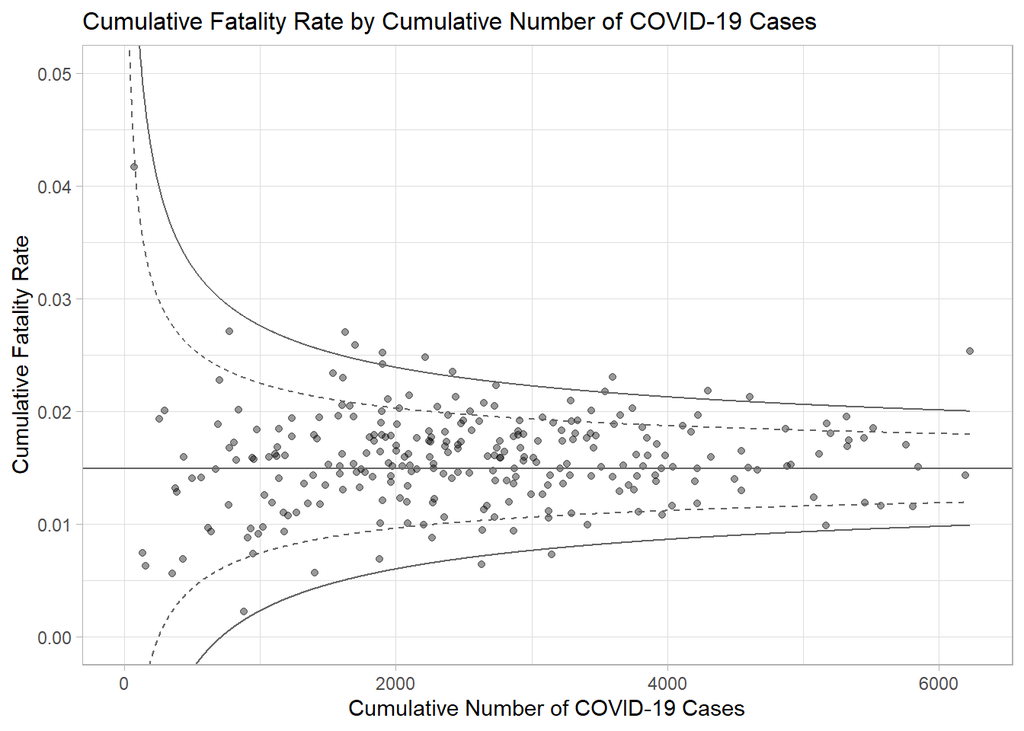

```r
p <- ggplot(df, aes(x = Positive, y = rate)) +
  geom_point(aes(label=`Sub-district`),
             alpha=0.4) +
  geom_line(data = dfCI,
            aes(x = number.seq,
                y = number.ll95),
            size = 0.4,
            colour = "grey40",
            linetype = "dashed") +
  geom_line(data = dfCI,
            aes(x = number.seq,
                y = number.ul95),
            size = 0.4,
            colour = "grey40",
            linetype = "dashed") +
  geom_line(data = dfCI,
            aes(x = number.seq,
                y = number.ll999),
            size = 0.4,
            colour = "grey40") +
  geom_line(data = dfCI,
            aes(x = number.seq,
                y = number.ul999),
            size = 0.4,
            colour = "grey40") +
  geom_hline(data = dfCI,
             aes(yintercept = fit.mean),
             size = 0.4,
             colour = "grey40") +
  coord_cartesian(ylim=c(0,0.05)) +
  annotate("text", x = 1, y = -0.13, label = "95%", size = 3, colour = "grey40") +
  annotate("text", x = 4.5, y = -0.18, label = "99%", size = 3, colour = "grey40") +
  ggtitle("Cumulative Fatality Rate by Cumulative Number of COVID-19 Cases") +
  xlab("Cumulative Number of COVID-19 Cases") +
  ylab("Cumulative Fatality Rate") +
  theme_light() +
  theme(plot.title = element_text(size=12),
        legend.position = c(0.91,0.85),
        legend.title = element_text(size=7),
        legend.text = element_text(size=7),
        legend.background = element_rect(colour = "grey60", linetype = "dotted"),
        legend.key.height = unit(0.3, "cm"))
p
```

### 4.5.4 Interactive Funnel Plot: plotly + ggplot2

The funnel plot created using ggplot2 functions can be made interactive with `ggplotly()` of **plotly** r package.

```r
fp_ggplotly <- ggplotly(p,
  tooltip = c("label",
              "x",
              "y"))
fp_ggplotly
```

[interactive chart not shown]

## 4.6 References

- [funnelPlotR](https://nhs-r-community.github.io/FunnelPlotR/index.html) package.
- [Funnel Plots for Indirectly-standardised ratios.](https://nhs-r-community.github.io/FunnelPlotR/articles/funnel_plots.html)
- [Changing funnel plot options](https://nhs-r-community.github.io/FunnelPlotR/articles/changing_funnel_plot_options.html)
- [ggplot2](https://ggplot2.tidyverse.org/) package.